# Models

Lukáš Častven, Michal Kilian

2025-04-29

Based on these EDA findings, as our first model, we choose simple decision trees. This model choice is supported by the EDA which identified some non-linear relationships (e.g., the threshold effect of securing `first_` objectives) and mixed data types (numeric `_diff`, `_champdiff`, `time_first_*`, categorical `first_*`). While features like `time_first_*` and `_champdiff` showed limited individual predictive power.

## Decision trees

```r
decision_tree <- function(formula, cp = 0.01) {
    # https://rdrr.io/cran/rpart/man/rpart.html
    tree_model <- rpart(
        formula = formula,
        data = train_data,
        method = "class",
        cp = cp
    )

    predictions <- predict(tree_model, newdata = test_data, type = "class")
    conf_matrix <- confusionMatrix(data = predictions, reference = test_data$team1_won)
    return (list(model = tree_model, conf_matrix = conf_matrix))
}

plot_decision_tree <- function(tree_model) {
    rpart.plot(
        tree_model,
        box.palette = c(color2, color1),
        main = "Predicting winner of a game by early game",
    )
}
```

We first try all features that shows promise in EDA (`first_` and diffs).

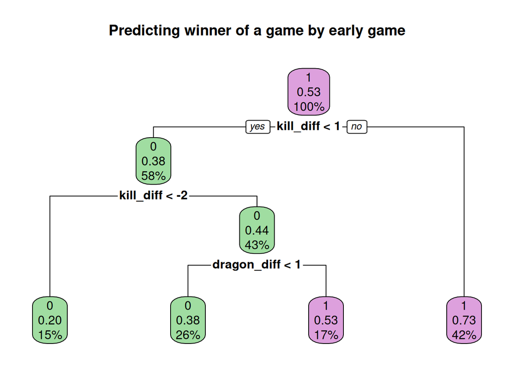

```r
formula <- team1_won ~ kill_diff + dragon_diff + rift_herald_diff +
  tower_diff + first_blood + first_dragon + first_herald +
  first_tower

all_tree <- decision_tree(formula)
plot_decision_tree(all_tree$model)
```

```r
all_tree$conf_matrix$overall['Accuracy']
```

```
##  Accuracy
## 0.6689456
```

```r
all_tree$conf_matrix
```

```
## Confusion Matrix and Statistics
##
##           Reference
## Prediction    0    1
##          0 2545 1234
##          1 1865 3717
##
##                Accuracy : 0.6689
##                  95% CI : (0.6593, 0.6785)
##     No Information Rate : 0.5289
##     P-Value [Acc > NIR] : < 2.2e-16
##
##                   Kappa : 0.3304
##
##  Mcnemar's Test P-Value : < 2.2e-16
##
##             Sensitivity : 0.5771
##             Specificity : 0.7508
##          Pos Pred Value : 0.6735
##          Neg Pred Value : 0.6659
##              Prevalence : 0.4711
##          Detection Rate : 0.2719
##    Detection Prevalence : 0.4037
##       Balanced Accuracy : 0.6639
##
##        'Positive' Class : 0
##
```

With the default settings it chose `kill_diff` and `dragon_diff`, which has accuracy 0.6689456. Next we will try to tune the `cp` parameter, which sets threshold for how much a tree split should improve the model (default was 0.01).

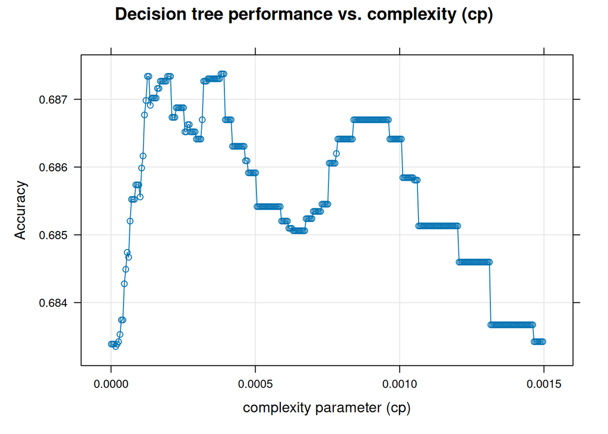

```r
set.seed(42069)

train_control <- trainControl(
  method = "cv",
  number = 10,
  savePredictions = "final"
)

tune_grid <- expand.grid(cp = seq(from = 0.000001, to = 0.0015, by = 0.000005))

tuned_tree_model <- train(
  form = formula,
  data = train_data,
  method = "rpart",
  trControl = train_control,
  tuneGrid = tune_grid,
  metric = "Accuracy"
)

plot(tuned_tree_model,
     main = "Decision tree performance vs. complexity (cp)",
     xlab = "complexity parameter (cp)",
     ylab = paste(tuned_tree_model$metric))
```

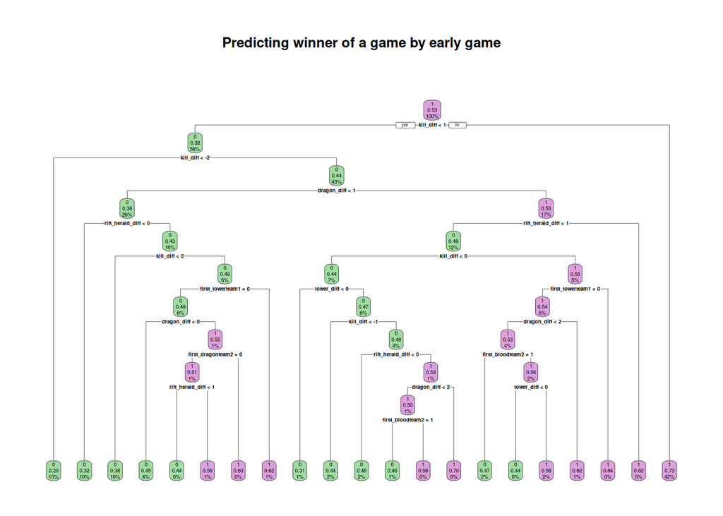

```r
plot_decision_tree(tuned_tree_model$finalModel)
```

```r
tuned_tree_model$bestTune
```

```
##          cp
## 79 0.000391
```

```r
tuned_tree_model$results[rownames(tuned_tree_model$bestTune),][['Accuracy']]
```

```
## [1] 0.6873746
```

The best tuned model had `cp = 0.000391` and accuracy 0.6873746, which is around 2% better. Not much of an improvement.

```r
logreg_model <- logistic_reg() %>%
    set_engine("glm") %>%
    set_mode("classification") %>%
    fit(team1_won ~ kill_diff, data = train_data)

predictions <- predict(logreg_model, new_data = test_data, type = "class")

conf_matrix <- confusionMatrix(data = predictions$.pred_class, reference = test_data$team1_won)

print(conf_matrix)
```

```
## Confusion Matrix and Statistics
##
##           Reference
## Prediction    0    1
##          0 2509 1240
##          1 1901 3711
##
##                Accuracy : 0.6645
##                  95% CI : (0.6548, 0.674)
##     No Information Rate : 0.5289
##     P-Value [Acc > NIR] : < 2.2e-16
##
##                   Kappa : 0.3211
##
##  Mcnemar's Test P-Value : < 2.2e-16
##
##             Sensitivity : 0.5689
##             Specificity : 0.7495
##          Pos Pred Value : 0.6692
##          Neg Pred Value : 0.6613
##              Prevalence : 0.4711
##          Detection Rate : 0.2680
##    Detection Prevalence : 0.4005
##       Balanced Accuracy : 0.6592
##
##        'Positive' Class : 0
##
```

We trained a random forest, but it took 26 minutes and the results were, little better than the decision tree.

The result

```
[1] "Training finished in: 26.83156 mins"
Random Forest

29960 samples
   11 predictor
    2 classes: '0', '1'

No pre-processing
Resampling: Bootstrapped (25 reps)
Summary of sample sizes: 29960, 29960, 29960, 29960, 29960, 29960, ...
Resampling results across tuning parameters:

  mtry  Accuracy   Kappa
   2    0.6807033  0.3579158
   8    0.6609411  0.3185253
  15    0.6562741  0.3094617

Accuracy was used to select the optimal model using the largest value.
The final value used for the model was mtry = 2.
```